# Comparison between `ALEPlot` and `ale` packages

## Real data with binary outcomes (ALEPlot Example 3)

The next code example from the `ALEPlot` package analyzes a real dataset with a binary outcome variable. Whereas the `ALEPlot` has the user load a CSV file that might not be readily available, we make that dataset available as the census dataset. We load it here with the adjustments necessary to run the `ALEPlot` example.

```r
## R code for Example 3
## Load relevant packages
library(ALEPlot)
library(gbm)
## Read data and fit a boosted tree supervised learning model
data(census, package = 'ale')  # load ale package version of the data
data <-
  census |>
  as.data.frame() |>   # ALEPlot is not compatible with the tibble format
  select(age:native_country, higher_income) |>  # Rearrange columns to match ALEPlot order
  na.omit(data)
```

Although gradient boosted trees generally perform quite well, they are rather slow. Rather than having you wait for it to run, the code here downloads a pretrained GBM model. However, the code used to generate it is provided in comments so that you can see it and run it yourself if you want to. Note that the model calls is based on `data[,-c(3,4)]`, which drops the third and fourth variables (`fnlwgt` and `education`, respectively).

```r
# To generate the code, uncomment the following lines.
# But it is slow, so this vignette loads a pre-created model object.
# set.seed(0)
# gbm.data <- gbm(higher_income ~ ., data= data[,-c(3,4)],
#                 distribution = "bernoulli", n.trees=6000, shrinkage=0.02,
#                 interaction.depth=3)
# saveRDS(gbm.data, file.choose())
gbm.data <- url('https://github.com/Tripartio/ale/raw/main/download/gbm.data_model.rds') |>
  readRDS()

gbm.data
```

```
#> gbm(formula = higher_income ~ ., distribution = "bernoulli",
#>     data = data[, -c(3, 4)], n.trees = 6000, interaction.depth = 3,
#>     shrinkage = 0.02)
#> A gradient boosted model with bernoulli loss function.
#> 6000 iterations were performed.
#> There were 12 predictors of which 12 had non-zero influence.
```

### ALEPlot code

As before, we create a custom prediction function and then call the `ALEPlot` function to generate the plots. The prediction type here is “link”, which represents the log odds in the `gbm` package.

Creation of the ALE plots here is rather slow because the `gbm` predict function is slow. In this example, only `age`, `education_num` (number of years of education), and `hours_per_week` are plotted, along with the interaction between `age` and `hours_per_week`.

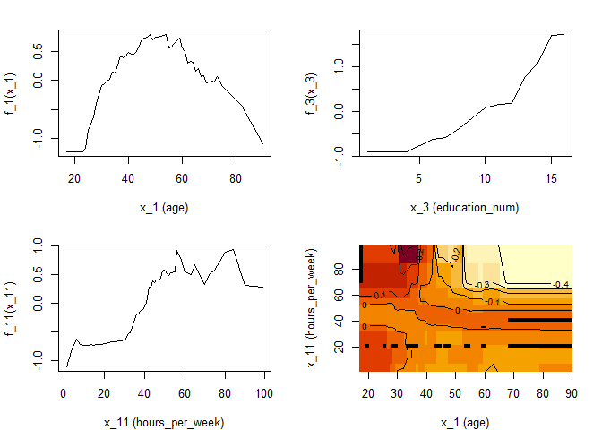

```r
## Define the predictive function; note the additional arguments for the
## predict function in gbm
yhat <- function(X.model, newdata) as.numeric(predict(X.model, newdata,
n.trees = 6000, type="link"))

## Calculate and plot the ALE main and interaction effects for x_1, x_3,
## x_11, and {x_1, x_11}
par(mfrow = c(2,2), mar = c(4,4,2,2)+ 0.1)
ALE.1=ALEPlot(data[,-c(3,4,15)], gbm.data, pred.fun=yhat, J=1, K=500,
NA.plot = TRUE)
ALE.3=ALEPlot(data[,-c(3,4,15)], gbm.data, pred.fun=yhat, J=3, K=500,
NA.plot = TRUE)
ALE.11=ALEPlot(data[,-c(3,4,15)], gbm.data, pred.fun=yhat, J=11, K=500,
NA.plot = TRUE)
ALE.1and11=ALEPlot(data[,-c(3,4,15)], gbm.data, pred.fun=yhat, J=c(1,11),
K=50, NA.plot = FALSE)
```

### `ale` package equivalent

Here is the analogous code using the `ale` package. In this case, we also need to define a custom predict function because of the particular `n.trees = 6000` argument. To speed things up, we provide a pretrained `ale` object. This is possible because `ale` returns objects with data and plots bundled together with no side effects (like automatic printing of created plots). (It is probably possible to similarly cache `ALEPlot` ALE objects, but it is not quite as straightforward.)

#### Log odds

We display all the plots because it is easy to do so with the `ale` package but we focus on `age`, `education_num`, and `hours_per_week` for comparison with ALEPlot. If the shapes of these plots look different, it is because `ale` tries as much as possible to display plots on the same y-axis coordinate scale for easy comparison across plots.

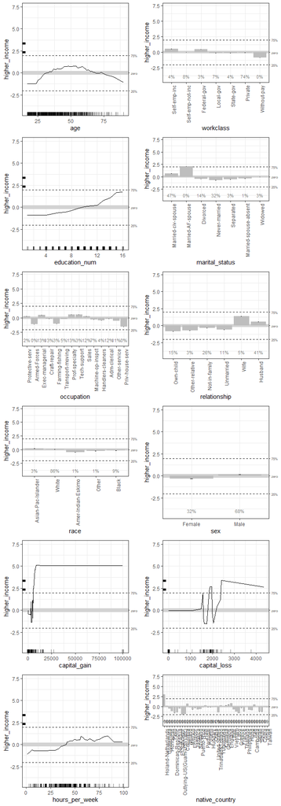

```r
# Custom predict function that returns log odds
yhat <- function(object, newdata) {
  as.numeric(
    predict(object, newdata,  n.trees = 6000,
            type="link")  # return log odds
  )
}

# Generate ALE data for all variables

# # To generate the code, uncomment the following lines.
# # But it is slow, so this vignette loads a pre-created model object.
# gbm_ale_link <- ale(
#   data[,-c(3,4)], gbm.data,
#   pred_fun = yhat,
#   x_intervals = 500,
#   rug_sample_size = 600,  # technical issue: rug_sample_size must be > x_intervals + 1
#   relative_y = 'zero'  # compatibility with ALEPlot
# )
# saveRDS(gbm_ale_link, file.choose())
gbm_ale_link <- url('https://github.com/Tripartio/ale/raw/main/download/gbm_ale_link.rds') |>
  readRDS()

# Print plots
gridExtra::grid.arrange(grobs = gbm_ale_link$plots, ncol = 2)
```

Now we generate ALE data for all two-way interactions and then plot them. Again, note the interaction between `age` and `hours_per_week`. The interaction is minimal except for the extremely high cases of hours per week.

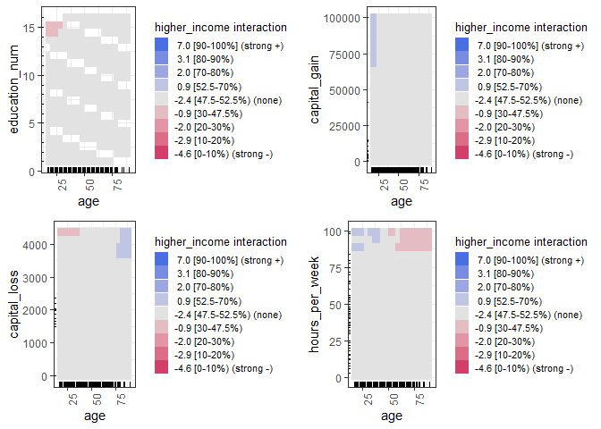

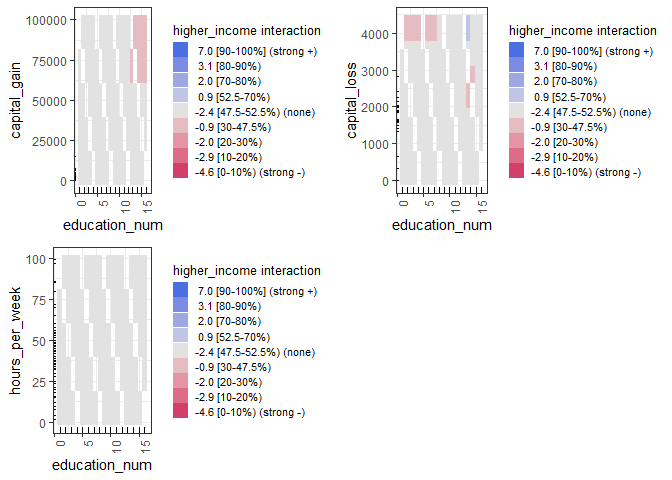

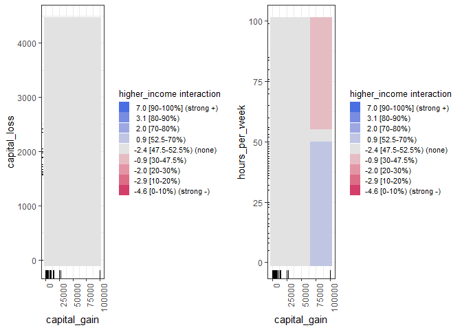

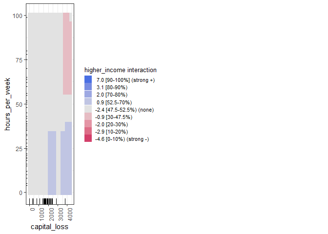

```r
# # To generate the code, uncomment the following lines.
# # But it is slow, so this vignette loads a pre-created model object.
# gbm_ale_ixn_link <- ale_ixn(
#   data[,-c(3,4)], gbm.data,
#   pred_fun = yhat,
#   x_intervals = 500,
#   rug_sample_size = 600,  # technical issue: rug_sample_size must be > x_intervals + 1
#   relative_y = 'zero'  # compatibility with ALEPlot
# )
# saveRDS(gbm_ale_ixn_link, file.choose())
gbm_ale_ixn_link <- url('https://github.com/Tripartio/ale/raw/main/download/gbm_ale_ixn_link.rds') |>
  readRDS()

# Print plots
gbm_ale_ixn_link$plots |>
  purrr::walk(\(.x1) {  # extract list of x1 ALE outputs
    gridExtra::grid.arrange(grobs = .x1, ncol = 2)  # plot all x1 interaction plots
  })
```

#### Predicted probabilities

Log odds are not necessarily the most interpretable way to express probabilities (though we will show shortly that they are sometimes uniquely valuable). So, we repeat the ALE creation using the “response” prediction type for probabilities and the default median centring of the plots.

As we can see, the shapes of the plots are similar, but the y axes are more easily interpretable as the probability (from 0 to 1) that a census respondent is in the higher income category. The median of around 10% or so indicates the median prediction of the GBM model: half of the respondents were predicted to have higher than a 10% likelihood of being higher income and half were predicted to have lower likelihood. The y-axis rug plots indicate that the predictions were generally rather extreme, either relatively close to 0 or 1, with few predictions in the middle.

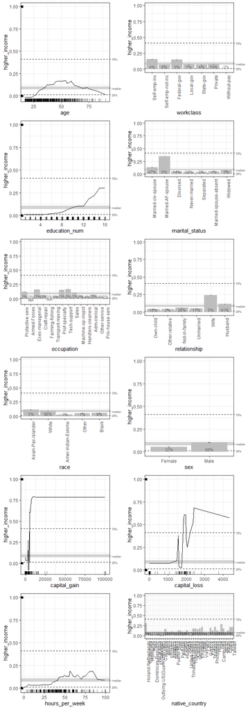

```r
# Custom predict function that returns predicted probabilities
yhat <- function(object, newdata) {
  as.numeric(
    predict(object, newdata,  n.trees = 6000,
            type="response")  # return predicted probabilities
  )
}

# Generate ALE data for all variables

# # To generate the code, uncomment the following lines.
# # But it is slow, so this vignette loads a pre-created model object.
# gbm_ale_prob <- ale(
#   data[,-c(3,4)], gbm.data,
#   pred_fun = yhat,
#   x_intervals = 500,
#   rug_sample_size = 600  # technical issue: rug_sample_size must be > x_intervals + 1
# )
# saveRDS(gbm_ale_prob, file.choose())
gbm_ale_prob <- url('https://github.com/Tripartio/ale/raw/main/download/gbm_ale_prob.rds') |>
  readRDS()

# Print plots
gridExtra::grid.arrange(grobs = gbm_ale_prob$plots, ncol = 2)
```

Finally, we again generate two-way interactions, this time based on probabilities instead of on log odds. However, probabilities might not be the best choice for indicating interactions because, as we see from the rugs in the one-way ALE plots, the GBM model heavily concentrates its probabilities in the extremes near 0 and 1. Thus, the plots’ suggestions of strong interactions are likely exaggerated. In this case, the log odds ALEs shown above are probably more relevant.

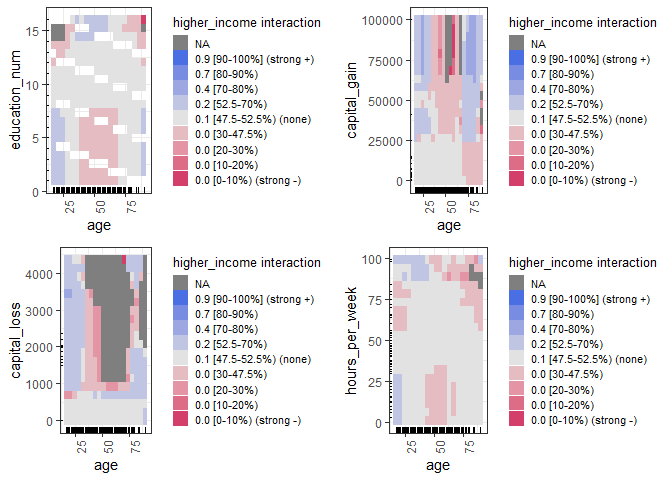

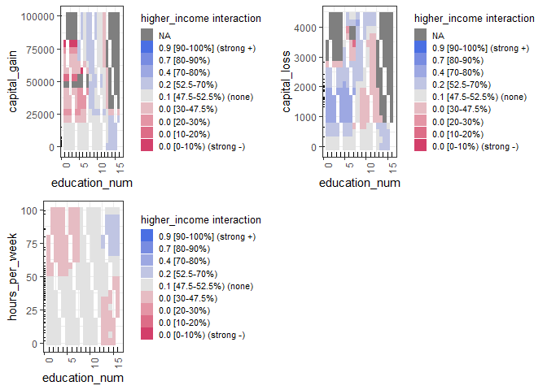

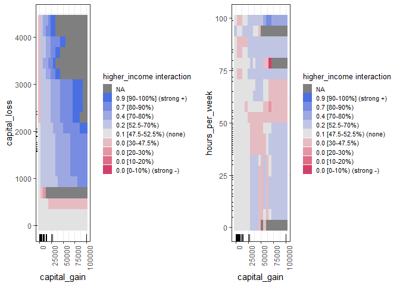

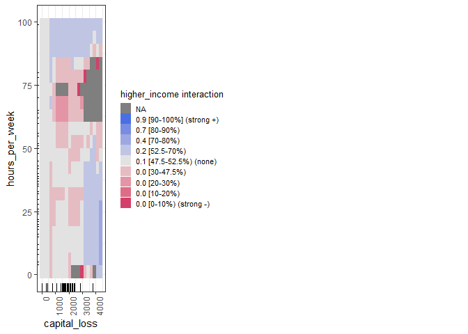

```r
# # To generate the code, uncomment the following lines.
# # But it is slow, so this vignette loads a pre-created model object.
# gbm_ale_ixn_prob <- ale_ixn(
#   data[,-c(3,4)], gbm.data,
#   pred_fun = yhat,
#   x_intervals = 500,
#   rug_sample_size = 600  # technical issue: rug_sample_size must be > x_intervals + 1
# )
# saveRDS(gbm_ale_ixn_prob, file.choose())
gbm_ale_ixn_prob <- url('https://github.com/Tripartio/ale/raw/main/download/gbm_ale_ixn_prob.rds') |>
  readRDS()

# Print plots
gbm_ale_ixn_prob$plots |>
  purrr::walk(\(.x1) {  # extract list of x1 ALE outputs
    gridExtra::grid.arrange(grobs = .x1, ncol = 2)  # plot all x1 plots
  })
```